# Comments for MEDB 5501, Week 8

## Review multiple comparisons issue

- Type I error: rejecting the null hypothesis when the null hypothesis is true.
  - Multiple simultaneous hypotheses increase the Type I error rate.

## Bonferroni inequality, 1 of 2

Start with two hypotheses. Define

- $E_1$ = Type I error for Hypothesis 1
- $E_2$ = Type I error for Hypothesis 2
  - $P[E_1\ \cup\ E_2]=P[E_1]+P[E_2]-P[E_1\ \cap\ E_2]$
  - $P[E_1\ \cup\ E_2]\ \le\ P[E_1]+P[E_2]$
  - $P[E_1\ \cup\ E_2]\ \le\ P[E_1]+P[E_2]$
  - $P[E_1\ \cup\ E_2]\ \le\ 2 \alpha$

## Bonferroni adjustment

- For m hypotheses
  - $P[E_1\ \cup\ ...\ \cup E_m]\ \le\ m \alpha$
- Test each hypothesis at $\alpha/m$
  - Preserves overall Type I error rate

## Controversies over Bonferroni adjustment

- Increases Type II errors
- Impractical for large values of m
- Works poorly for highly correlated tests
- Ambiguity in definition of simultaneous hypotheses

## Alternatives to Bonferroni adjustment

- False discovery rate
- Designation of primary and secondary outcomes
- Subjective assessment of simultaneous hypotheses

## Review two-sample t-test

- $H_0:\ \mu_1=\mu_2$
- $H_1:\ \mu_1 \ne \mu_2$
  - Or a one tailed alternative
- $T=\frac{\bar X_1-\bar X_2}{SE(\bar X_1-\bar X_2)}$
  - Accept H0 if T is close to zero.

## What to do with three or more groups?

- $H_0:\ \mu_1=\mu_2=...=\mu_k$
- $H_1:\ \mu_i \ne \mu_j$ for some i, j
  - Note: one-tailed test is tricky.
- Accept H0 if the F ratio (defined below) is close to 1.

## Important assumptions

- Same as independent-samples t-test
  - Normality
  - Equal variances
  - Independence

## Post hoc tests

- If you reject H0, which values are unequal
  - With k groups, there are k(k-1)/2 comparisons
- Studentized range (Tukey test)
- Bonferroni adjustment

## Artificial data

```
   g  y
1  1 23
2  1 30
3  1 25
4  2 33
5  2 36
6  2 41
7  2 37
8  2 43
9  3 24
10 3 29
11 3 31
```

## Scatterplot

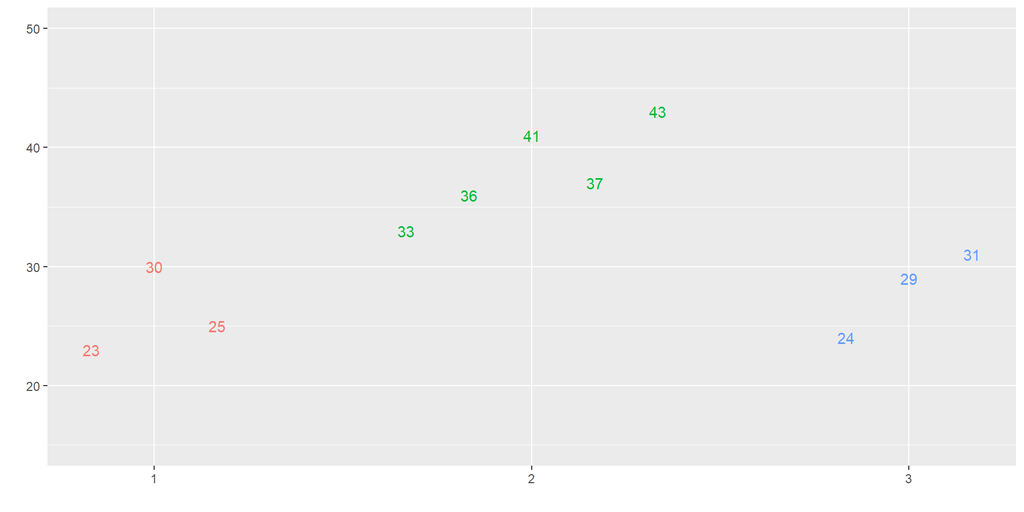

## Total SS = 452

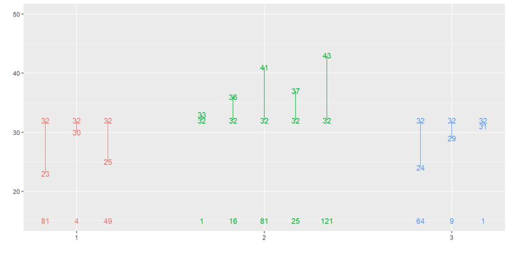

## Within SS = 116

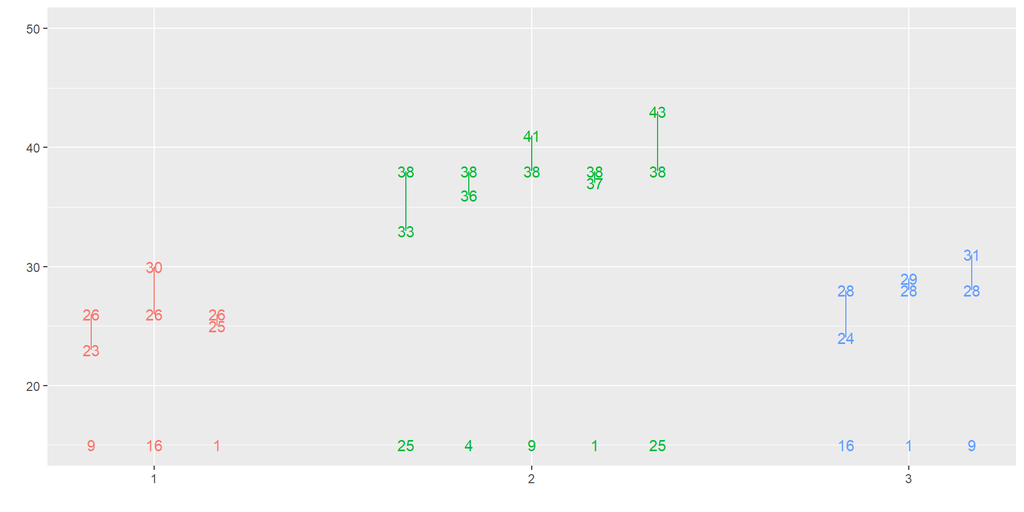

## Between SS = 336

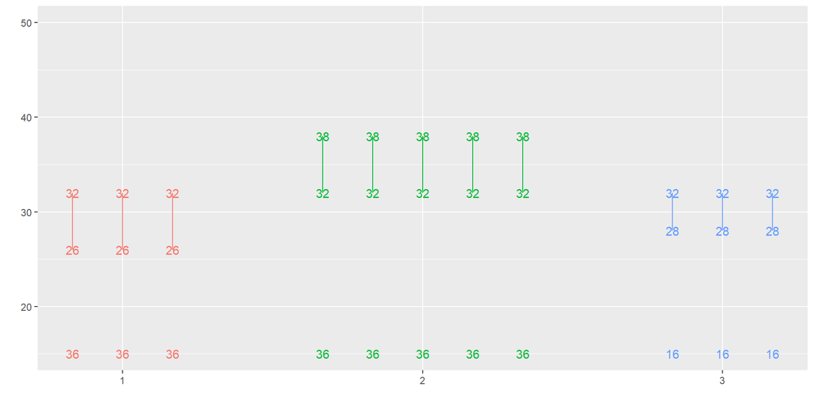

## Degrees of freedom

- For Total SS, df = 10
- For Within SS, df = 8
- For Between SS, df = 2
- In general,
  - N = number of observations
  - k = number of groups
    - Total df = N-1
    - Within df = N-k
    - Between df = k-1

## ANOVA table, 1 of 4

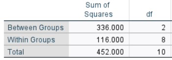

## ANOVA table, 2 of 4

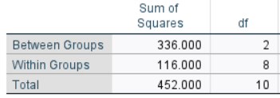

## ANOVA table, 3 of 4

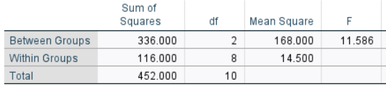

## ANOVA table, 4 of 4

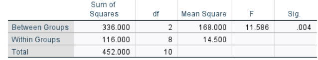

## ANOVA table from the general linear model

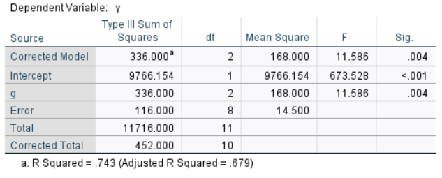